# Презентация по лабораторной работе №5

Основы информационной безопасности

Бызова М. О.

Российский университет дружбы народов, Москва, Россия

13 апреля 2025

# Информация

## Цель

Изучение механизмов изменения идентификаторов, применения SetUID- и Sticky-битов. Получение практических навыков работы в кон- соли с дополнительными атрибутами. Рассмотрение работы механизма смены идентификатора процессов пользователей, а также влияние бита Sticky на запись и удаление файлов.

## Выполнение лабораторной работы

Создание файла simpled.c и запись в файл кода

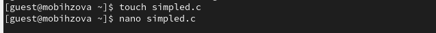

Создание файла

## Выполнение лабораторной работы

Компилирую файл, проверяю, что он скомпилировался

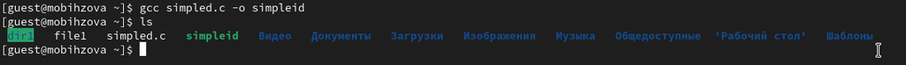

Компиляция файла

## Выполнение лабораторной работы

Запускаю исполняемый файл. В выводе файла выписыны номера пользоватея и групп, от вывода при вводе if, они отличаются только тем, что информации меньше

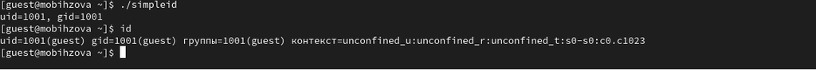

Сравнение команд

## Выполнение лабораторной работы

Создание, запись в файл и компиляция файла simpled2.c. Запуск программы

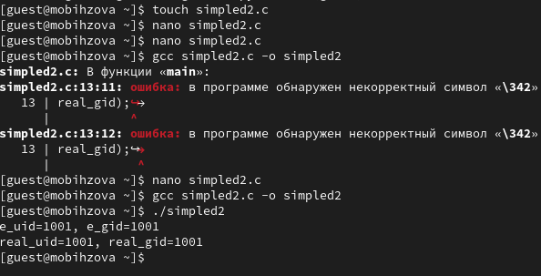

Создание и компиляция файла

## Выполнение лабораторной работы

С помощью chown изменяю владельца файла на суперпользователя, с помощью chmod изменяю права доступа

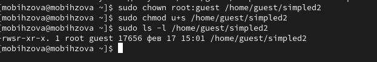

Смена владельца файла и прав доступа к файлу

## Выполнение лабораторной работы

Сравнение вывода программы и команды id, наша команда снова вывела только ограниченное количество информации

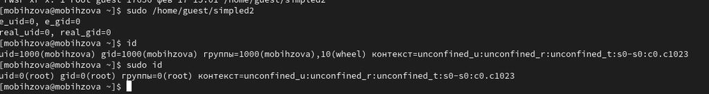

Запуск файла

## Выполнение лабораторной работы

Создание и компиляция файла readfile.c

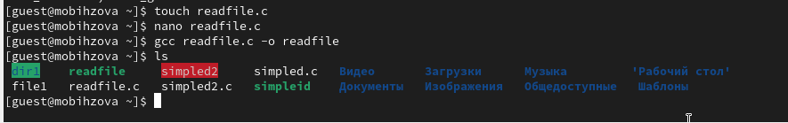

Создание и компиляция файла

## Выполнение лабораторной работы

Снова от имени суперпользователи меняю владельца файла readfile. Далее меняю права доступа так, чтобы пользователь guest не смог прочесть содержимое файла

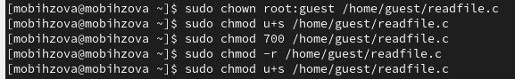

Смена владельца файла и прав доступа к файлу

## Выполнение лабораторной работы

Проверка прочесть файл от имени пользователя guest. Прочесть файл не удается

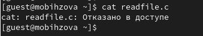

Попытка прочесть содержимое файла

## Выполнение лабораторной работы

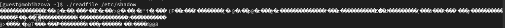

Попытка прочесть содержимое файла программой

## Выполнение лабораторной работы

Проверяем папку tmp на наличие атрибута Sticky, т.к. в выводе есть буква t, то атрибут установлен

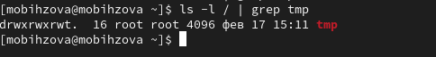

Проверка атрибутов директории tmp

## Выполнение лабораторной работы

От имени пользователя guest создаю файл с текстом, добавляю права на чтение и запись для других пользователей

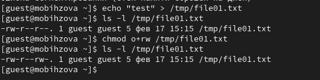

Создание файла, изменение прав доступа

## Выполнение лабораторной работы

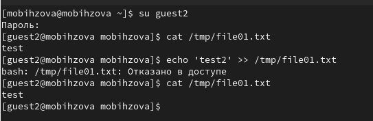

Попытка чтения файла

## Выполнение лабораторной работы

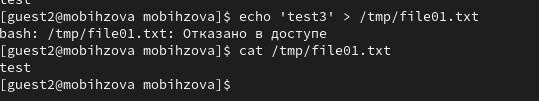

Попытка записи в файл

## Выполнение лабораторной работы

Далее пробуем удалить файл, снова получаем отказ

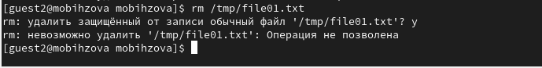

Попытка удалить файл

## Выполнение лабораторной работы

От имени суперпользователя снимаем с директории атрибут Sticky

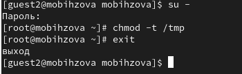

Смена атрибутов файла

## Выполнение лабораторной работы

Далее был выполнен повтор предыдущих действий. По результатам без Sticky-бита запись в файл и дозапись в файл осталась невозможной, зато удаление файла прошло успешно

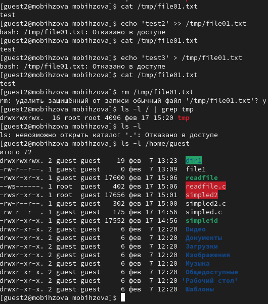

Повтор предыдущих действий

## Вывод

Изучила механизм изменения идентификаторов, применила SetUID- и Sticky-биты. Получила практические навыки работы в кон- соли с дополнительными атрибутами. Рассмотрела работы механизма смены идентификатора процессов пользователей, а также влияние бита Sticky на запись и удаление файлов.